# PGS Educational Attainment

### RAVLT Percentage Forgetting

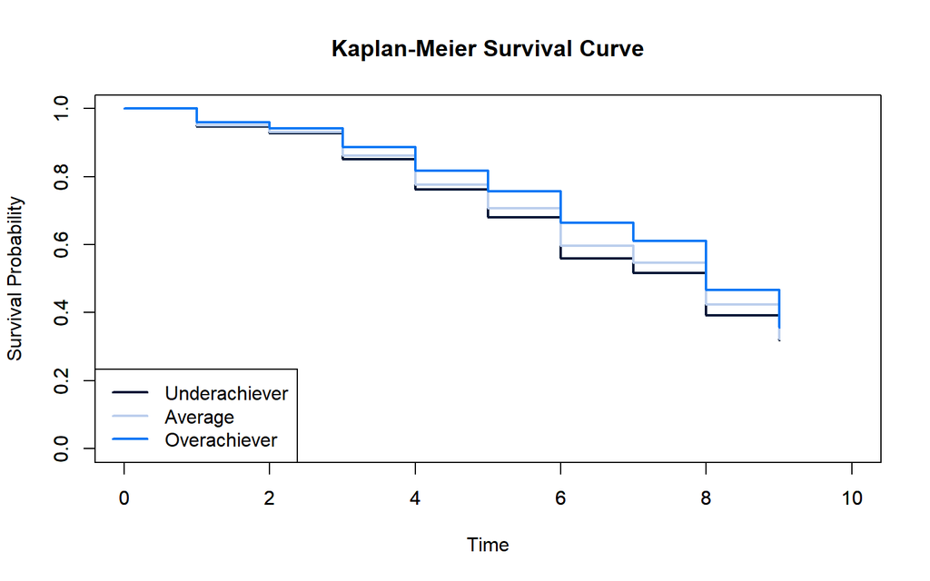

```
## Call:
## survdiff(formula = Surv(as.integer(VISCODE), RAVLT_perc_forgetting_cut) ~
##     thirtile_res, data = .)
##
## n=7290, 27 observations deleted due to missingness.
##
##                   N Observed Expected (O-E)^2/E (O-E)^2/V
## thirtile_res=1 3642     1216     1072      19.4      40.8
## thirtile_res=3 3648      940     1084      19.2      40.8
##
##  Chisq= 40.8  on 1 degrees of freedom, p= 2e-10
```

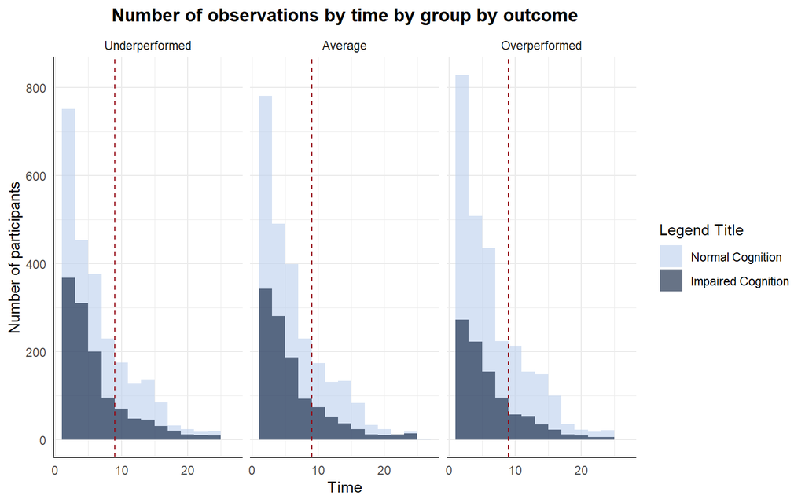

### RAVLT Forgetting

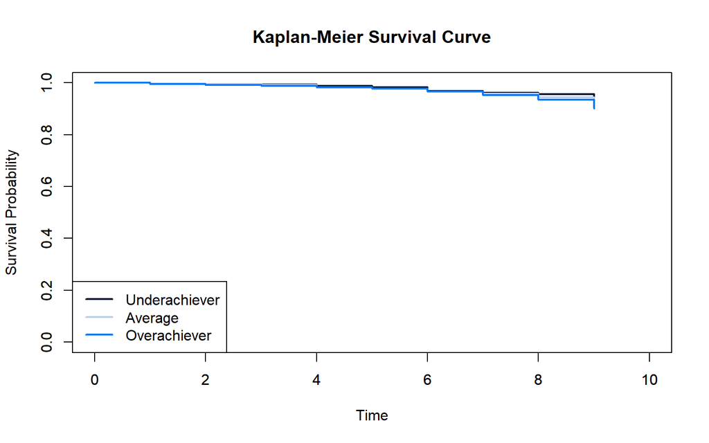

```
## Call:
## survdiff(formula = Surv(as.integer(VISCODE), RAVLT_forgetting_cut) ~
##     thirtile_res, data = .)
##
## n=7299, 18 observations deleted due to missingness.
##
##                   N Observed Expected (O-E)^2/E (O-E)^2/V
## thirtile_res=1 3651       68     83.5      2.89      5.77
## thirtile_res=3 3648      100     84.5      2.85      5.77
##
##  Chisq= 5.8  on 1 degrees of freedom, p= 0.02
```

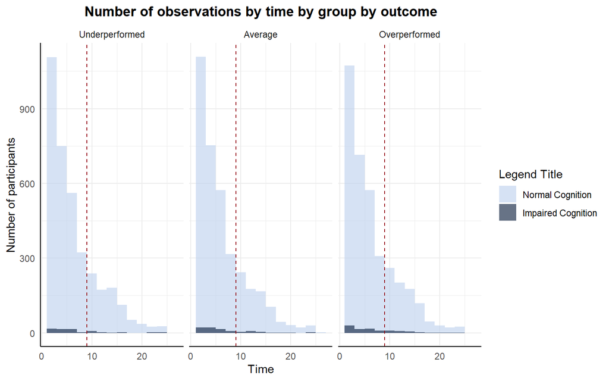

### RAVLT Learning

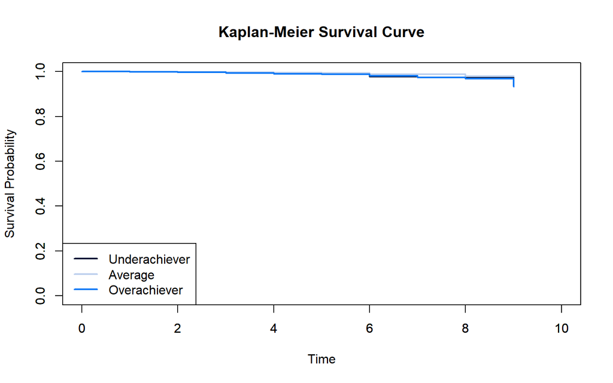

```
## Call:
## survdiff(formula = Surv(as.integer(VISCODE), RAVLT_learning_cut) ~
##     thirtile_res, data = .)
##
## n=7299, 18 observations deleted due to missingness.
##
##                   N Observed Expected (O-E)^2/E (O-E)^2/V
## thirtile_res=1 3651       39     44.2     0.608      1.21
## thirtile_res=3 3648       50     44.8     0.599      1.21
##
##  Chisq= 1.2  on 1 degrees of freedom, p= 0.3
```

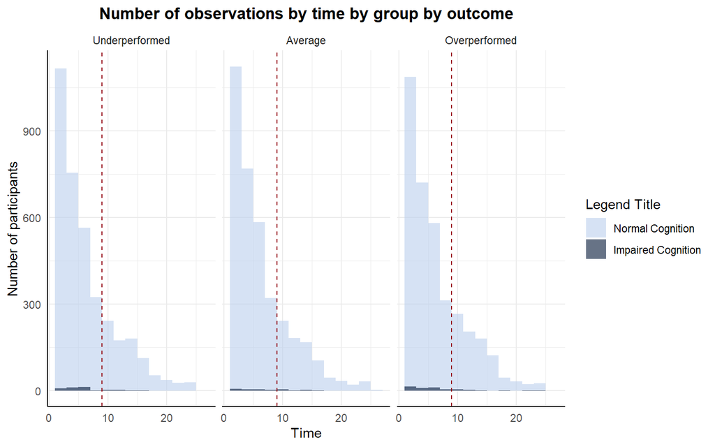

## TRABSCORE

The Trail Making Test is a neuropsychological test of visual attention and task switching. It has two parts, in which the subject is instructed to connect a set of 25 dots as quickly as possible while maintaining accuracy.

The test can provide information about visual search speed, scanning, speed of processing, mental flexibility, and executive functioning. It is sensitive to cognitive impairment associated with dementia, including Alzheimer’s disease. (ChatGPT)

Record the total number of seconds to complete Part B (*Trails B*), up to a maximum of 300 seconds. If the participant is not finished by 300 seconds, the score is 300.

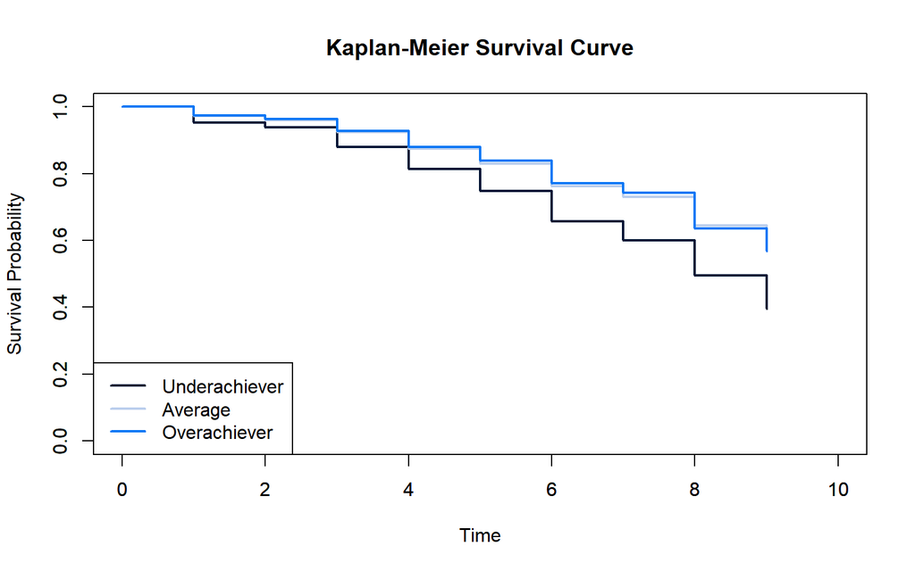

```
## Call:
## survdiff(formula = Surv(as.integer(VISCODE), TRABSCOR_cut) ~
##     thirtile_res, data = .)
##
## n=7252, 65 observations deleted due to missingness.
##
##                   N Observed Expected (O-E)^2/E (O-E)^2/V
## thirtile_res=1 3619      933      738      51.3       106
## thirtile_res=3 3633      554      749      50.6       106
##
##  Chisq= 106  on 1 degrees of freedom, p= <2e-16
```

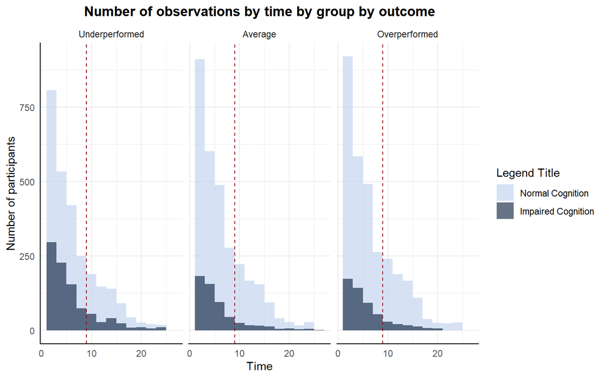

## Patient’s Everyday Cognition (EcogPt)

The original version of the ECog is an informant-based measure of cognitively-relevant everyday abilities comprised of 39 items, covering six cognitively-relevant domains: Everyday Memory, Everyday Language, Everyday Visuospatial Abilities, and Everyday Planning, Everyday Organization, and Everyday Divided Attention. Ratings are made on a four-point scale: 1 = better or no change compared to 10 years earlier, 2 = questionable/occasionally worse, 3 = consistently a little worse, 4 = consistently much worse. ([Tomaszewski Farias et al., 2012](https://www.ncbi.nlm.nih.gov/pmc/articles/PMC3211103/))

### EcogPt Everyday Divided Attention

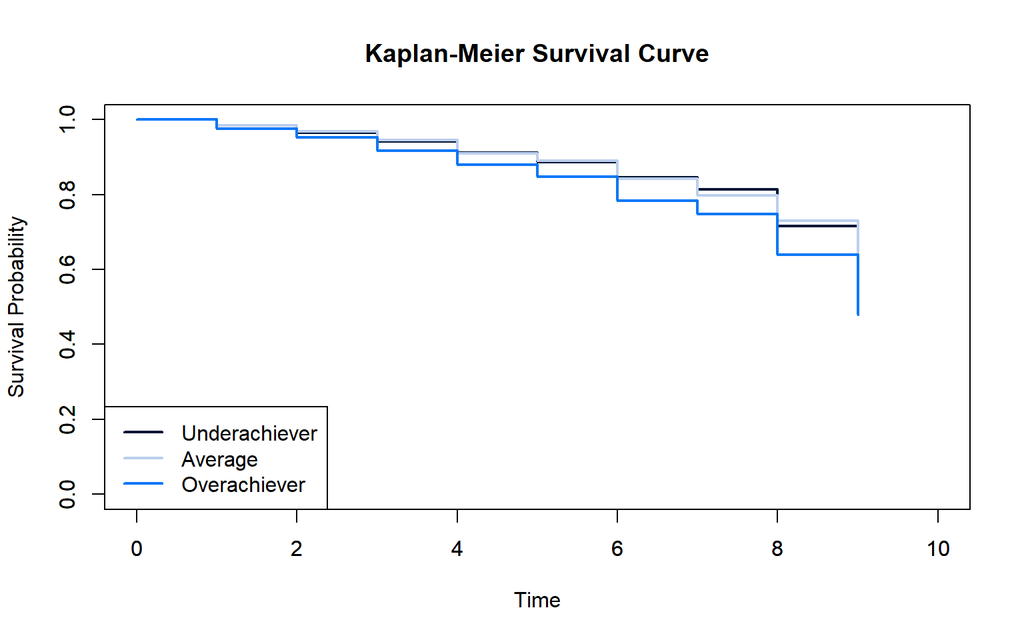

```
## Call:
## survdiff(formula = Surv(as.integer(VISCODE), EcogPtDivatt_cut) ~
##     thirtile_res, data = .)
##
## n=3888, 3429 observations deleted due to missingness.
##
##                   N Observed Expected (O-E)^2/E (O-E)^2/V
## thirtile_res=1 1820      194      222      3.44       6.7
## thirtile_res=3 2068      272      244      3.11       6.7
##
##  Chisq= 6.7  on 1 degrees of freedom, p= 0.01
```

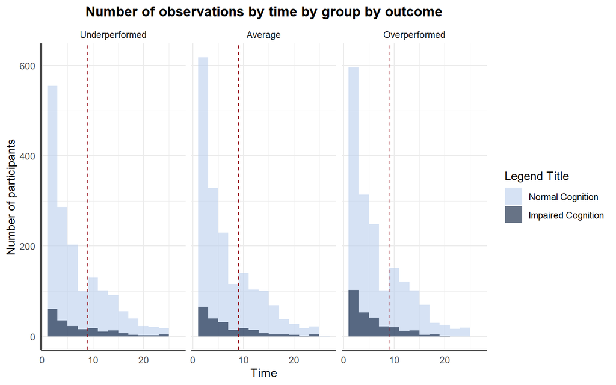

### EcogPt Everyday Language

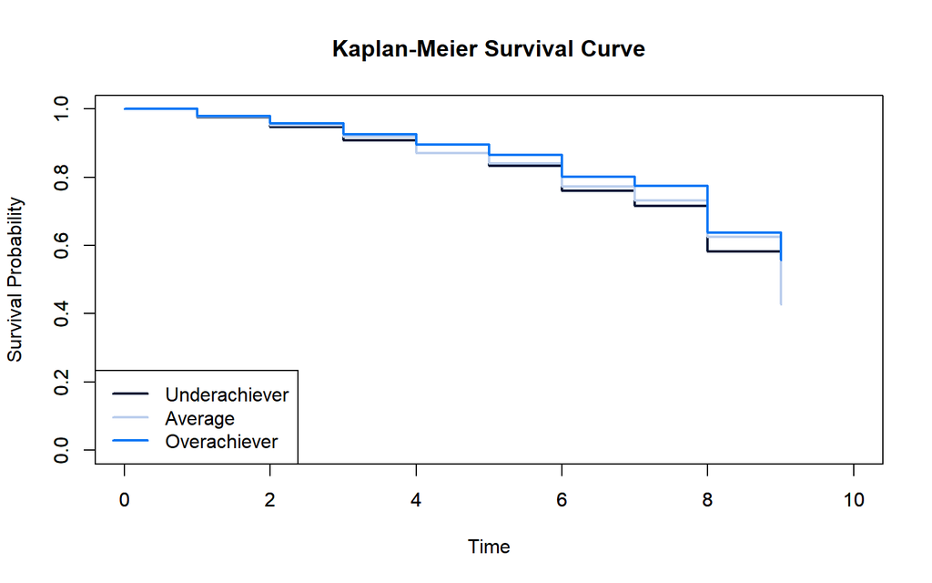

```
## Call:
## survdiff(formula = Surv(as.integer(VISCODE), EcogPtLang_cut) ~
##     thirtile_res, data = .)
##
## n=3919, 3398 observations deleted due to missingness.
##
##                   N Observed Expected (O-E)^2/E (O-E)^2/V
## thirtile_res=1 1830      309      273      4.63      9.11
## thirtile_res=3 2089      266      302      4.20      9.11
##
##  Chisq= 9.1  on 1 degrees of freedom, p= 0.003
```

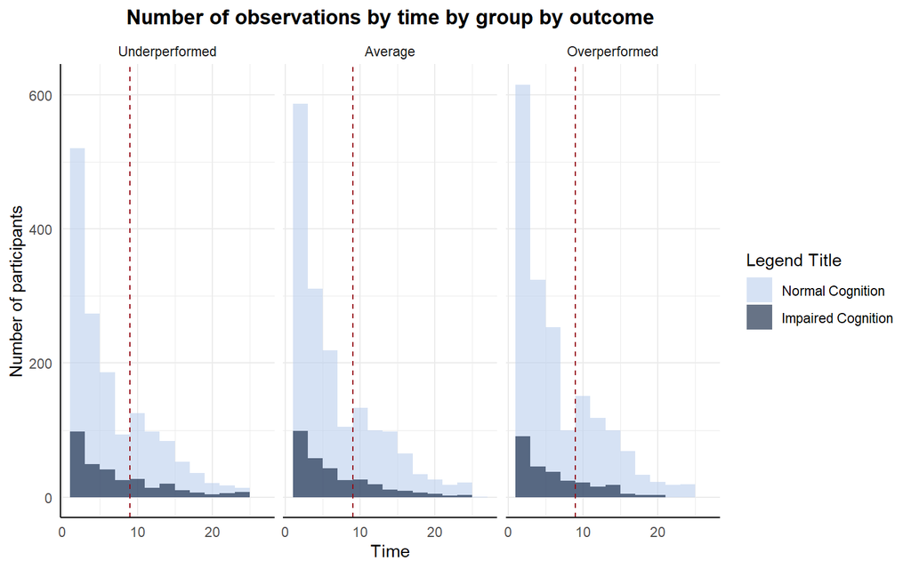

### EcogPt Everyday Memory

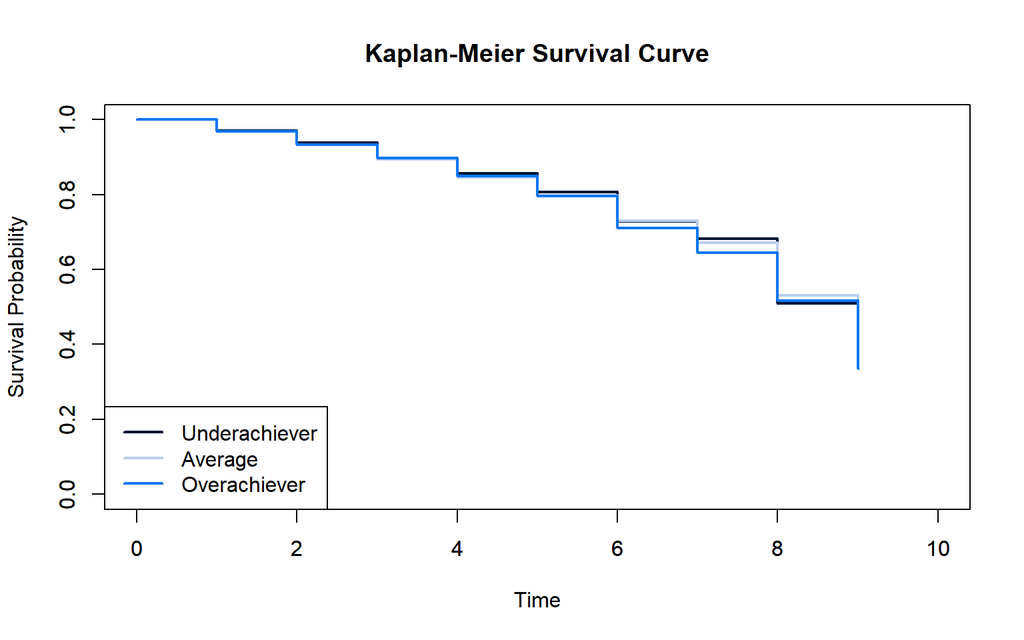

```
## Call:
## survdiff(formula = Surv(as.integer(VISCODE), EcogPtMem_cut) ~
##     thirtile_res, data = .)
##
## n=3925, 3392 observations deleted due to missingness.
##
##                   N Observed Expected (O-E)^2/E (O-E)^2/V
## thirtile_res=1 1828      341      349     0.188      0.37
## thirtile_res=3 2097      396      388     0.169      0.37
##
##  Chisq= 0.4  on 1 degrees of freedom, p= 0.5
```

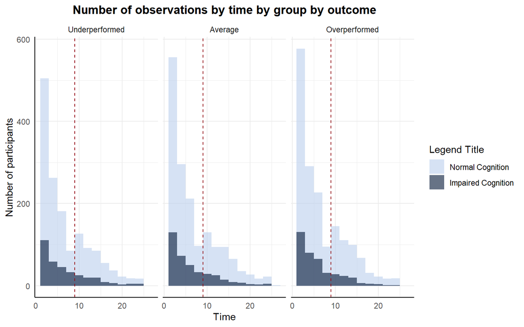

### EcogPt Everyday Organization

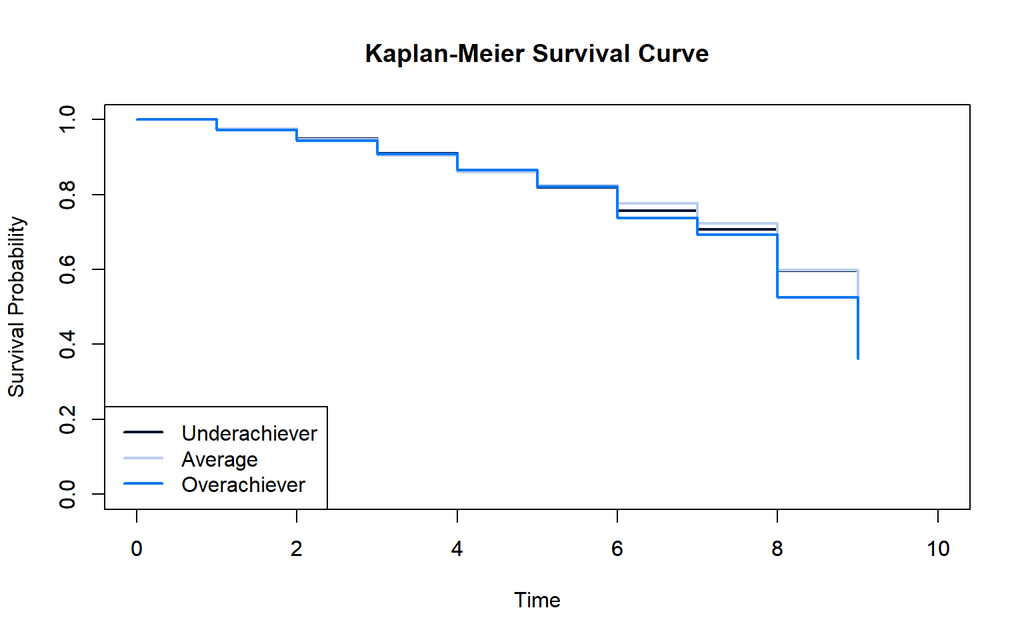

```
## Call:
## survdiff(formula = Surv(as.integer(VISCODE), EcogPtOrgan_cut) ~
##     thirtile_res, data = .)
##
## n=3855, 3462 observations deleted due to missingness.
##
##                   N Observed Expected (O-E)^2/E (O-E)^2/V
## thirtile_res=1 1787      299      319      1.26      2.48
## thirtile_res=3 2068      377      357      1.13      2.48
##
##  Chisq= 2.5  on 1 degrees of freedom, p= 0.1
```

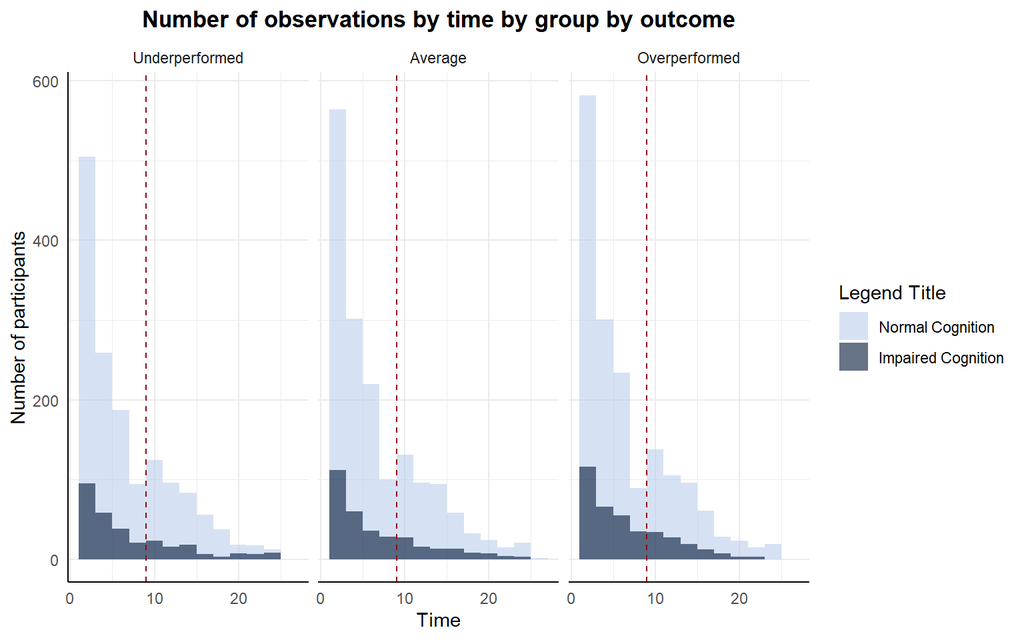

### EcogPt Everyday Planning

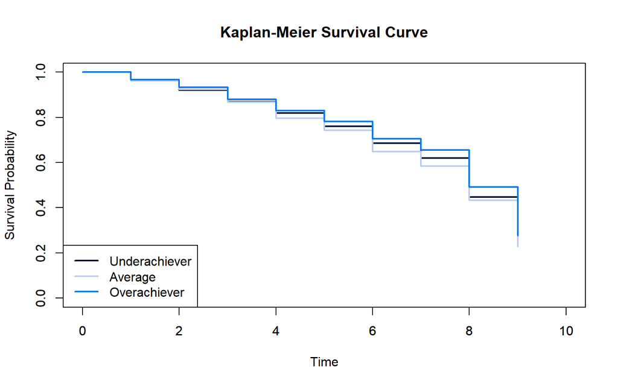

```
## Call:
## survdiff(formula = Surv(as.integer(VISCODE), EcogPtPlan_cut) ~
##     thirtile_res, data = .)
##
## n=3915, 3402 observations deleted due to missingness.
##
##                   N Observed Expected (O-E)^2/E (O-E)^2/V
## thirtile_res=1 1828      442      415      1.74      3.48
## thirtile_res=3 2087      431      458      1.58      3.48
##
##  Chisq= 3.5  on 1 degrees of freedom, p= 0.06
```

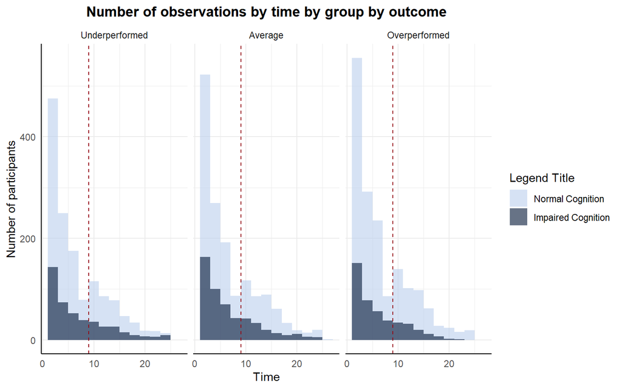

### EcogPt Everyday Visuospatial Abilities

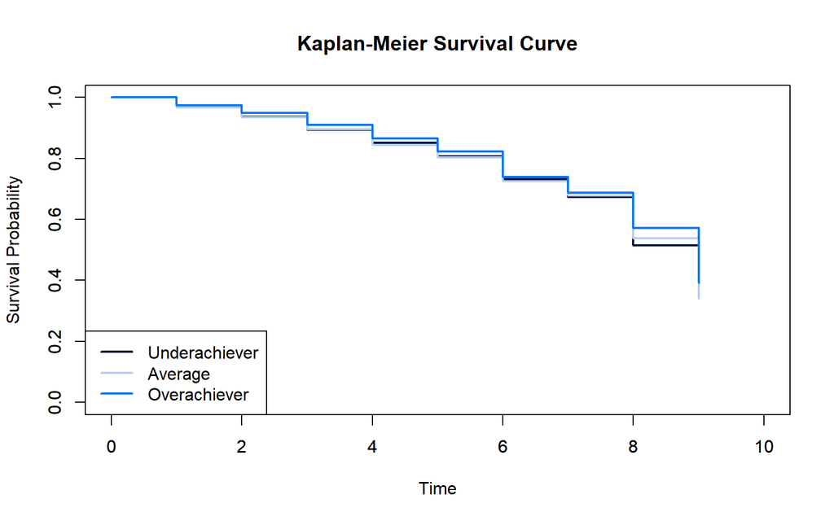

```
## Call:
## survdiff(formula = Surv(as.integer(VISCODE), EcogPtVisspat_cut) ~
##     thirtile_res, data = .)
##
## n=3897, 3420 observations deleted due to missingness.
##
##                   N Observed Expected (O-E)^2/E (O-E)^2/V
## thirtile_res=1 1827      351      335     0.719      1.43
## thirtile_res=3 2070      350      366     0.660      1.43
##
##  Chisq= 1.4  on 1 degrees of freedom, p= 0.2
```

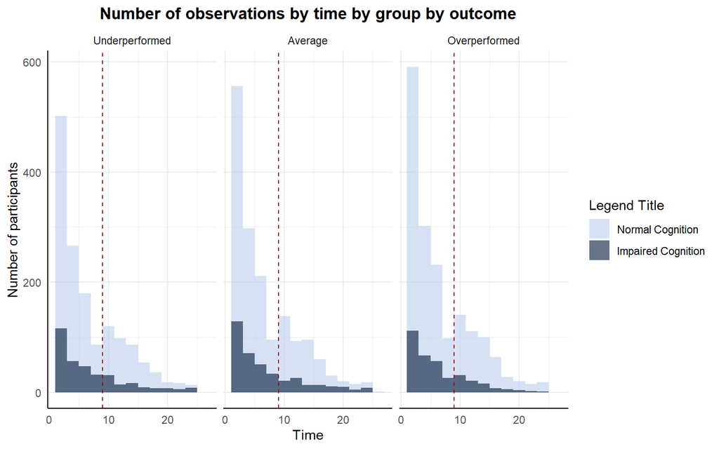

### EcogPt Total ???

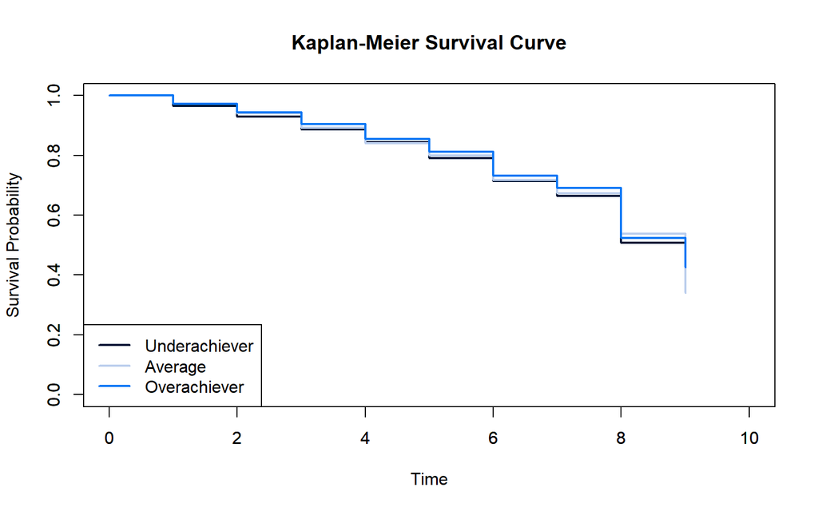

```
## Call:
## survdiff(formula = Surv(as.integer(VISCODE), EcogPtTotal_cut) ~
##     thirtile_res, data = .)
##
## n=3919, 3398 observations deleted due to missingness.
##
##                   N Observed Expected (O-E)^2/E (O-E)^2/V
## thirtile_res=1 1830      366      356     0.258     0.512
## thirtile_res=3 2089      384      394     0.234     0.512
##
##  Chisq= 0.5  on 1 degrees of freedom, p= 0.5
```

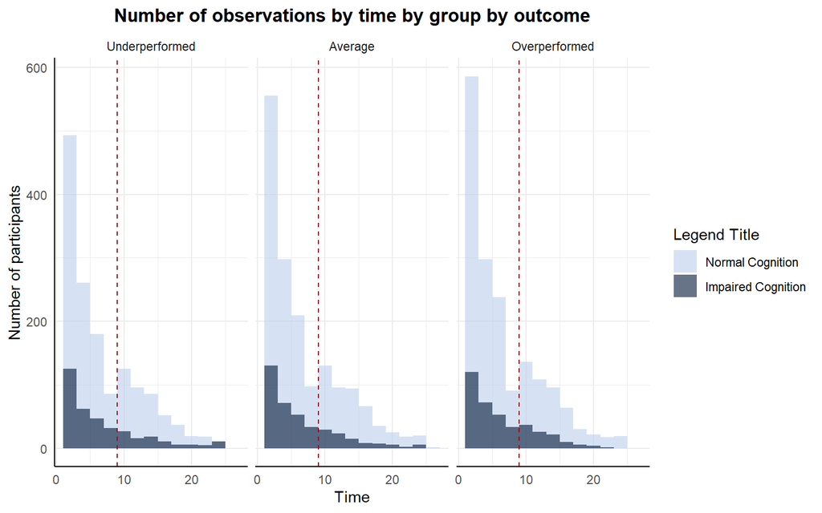

## Self-Reported Everyday Cognitive Abilities Questionnaire (EcogSP)

### EcogSP Everyday Divided Attention

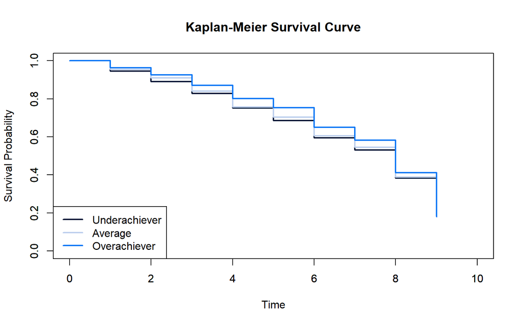

```
## Call:
## survdiff(formula = Surv(as.integer(VISCODE), EcogSPDivatt_cut) ~
##     thirtile_res, data = .)
##
## n=3913, 3404 observations deleted due to missingness.
##
##                   N Observed Expected (O-E)^2/E (O-E)^2/V
## thirtile_res=1 1843      632      574      5.76        12
## thirtile_res=3 2070      558      616      5.37        12
##
##  Chisq= 12  on 1 degrees of freedom, p= 5e-04
```

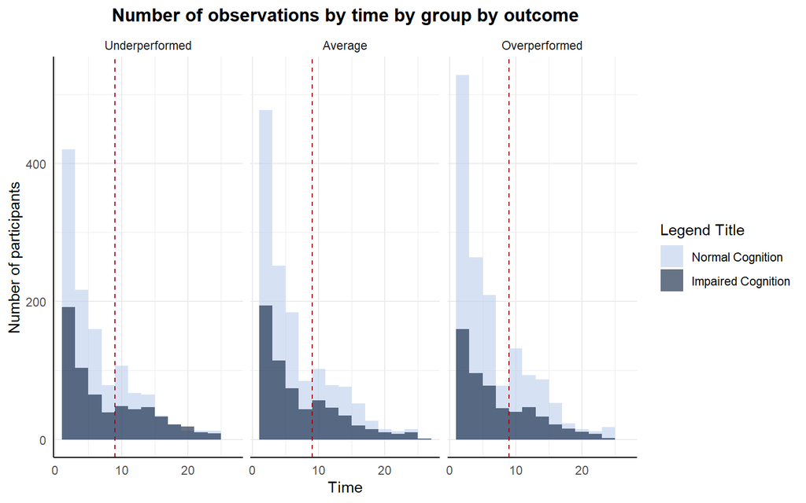

### EcogSP Everyday Language

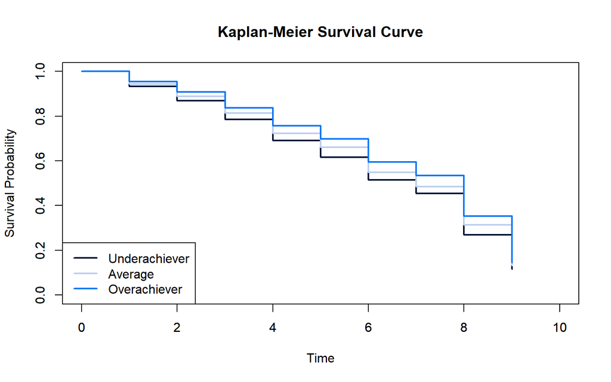

```
## Call:
## survdiff(formula = Surv(as.integer(VISCODE), EcogSPLang_cut) ~
##     thirtile_res, data = .)
##
## n=3989, 3328 observations deleted due to missingness.
##
##                   N Observed Expected (O-E)^2/E (O-E)^2/V
## thirtile_res=1 1872      771      702      6.71      14.1
## thirtile_res=3 2117      683      752      6.27      14.1
##
##  Chisq= 14.1  on 1 degrees of freedom, p= 2e-04
```

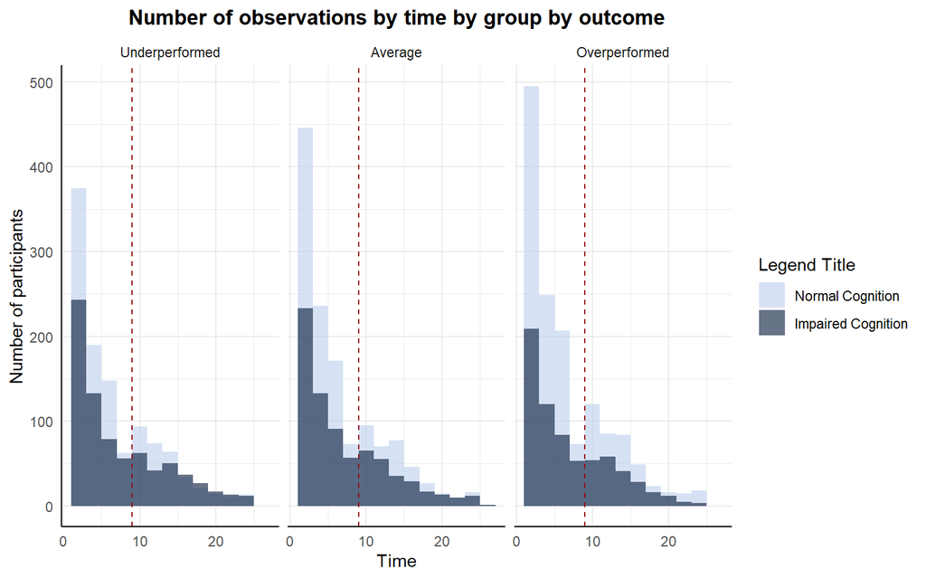

### EcogSP Everyday Memory

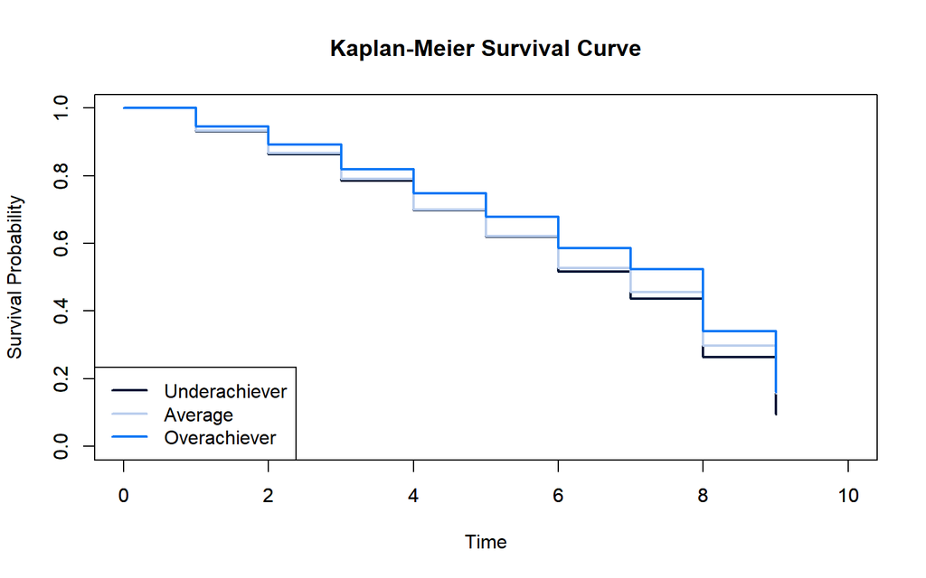

```
## Call:
## survdiff(formula = Surv(as.integer(VISCODE), EcogSPMem_cut) ~
##     thirtile_res, data = .)
##
## n=3989, 3328 observations deleted due to missingness.
##
##                   N Observed Expected (O-E)^2/E (O-E)^2/V
## thirtile_res=1 1872      761      707      4.18      8.75
## thirtile_res=3 2117      702      756      3.90      8.75
##
##  Chisq= 8.8  on 1 degrees of freedom, p= 0.003
```

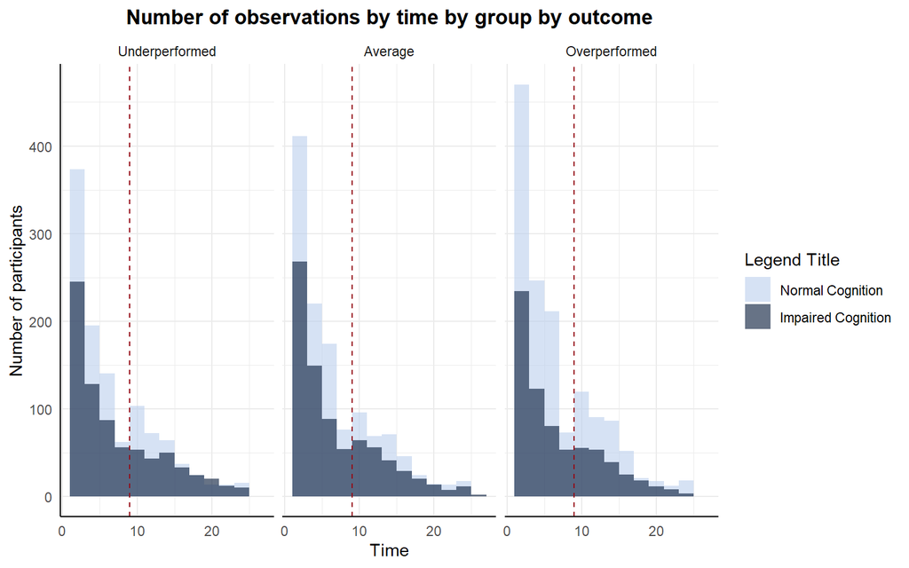

### EcogSP Everyday Organization

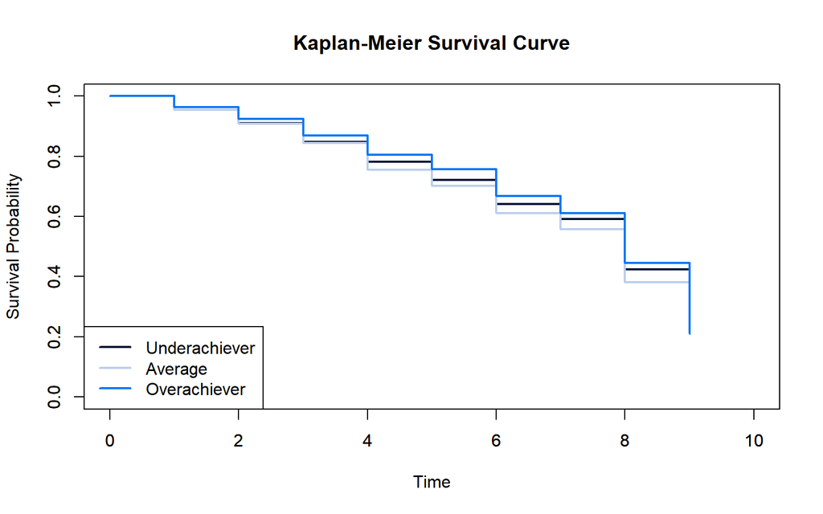

```
## Call:
## survdiff(formula = Surv(as.integer(VISCODE), EcogSPOrgan_cut) ~
##     thirtile_res, data = .)
##
## n=3850, 3467 observations deleted due to missingness.
##
##                   N Observed Expected (O-E)^2/E (O-E)^2/V
## thirtile_res=1 1791      532      505      1.42      2.92
## thirtile_res=3 2059      523      550      1.31      2.92
##
##  Chisq= 2.9  on 1 degrees of freedom, p= 0.09
```

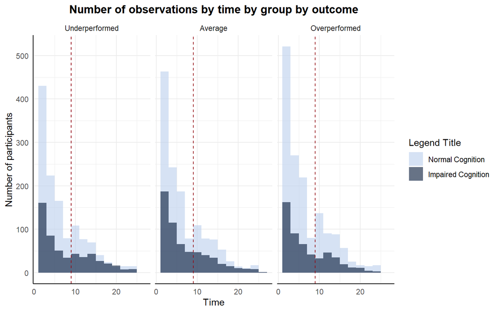

### EcogSP Everyday Planning

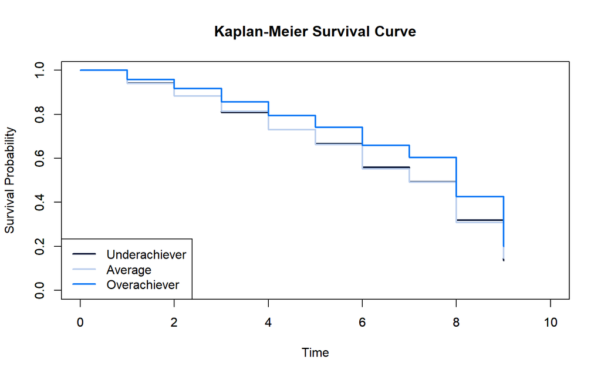

```
## Call:
## survdiff(formula = Surv(as.integer(VISCODE), EcogSPPlan_cut) ~
##     thirtile_res, data = .)
##
## n=3959, 3358 observations deleted due to missingness.
##
##                   N Observed Expected (O-E)^2/E (O-E)^2/V
## thirtile_res=1 1855      701      621     10.23      21.4
## thirtile_res=3 2104      587      667      9.53      21.4
##
##  Chisq= 21.4  on 1 degrees of freedom, p= 4e-06
```

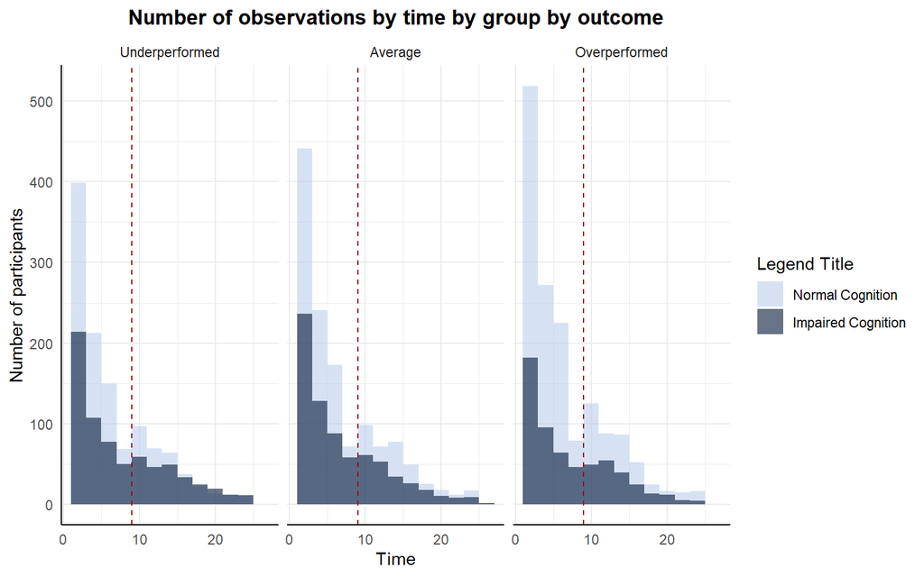

### EcogSP Everyday Visuospatial Abilities

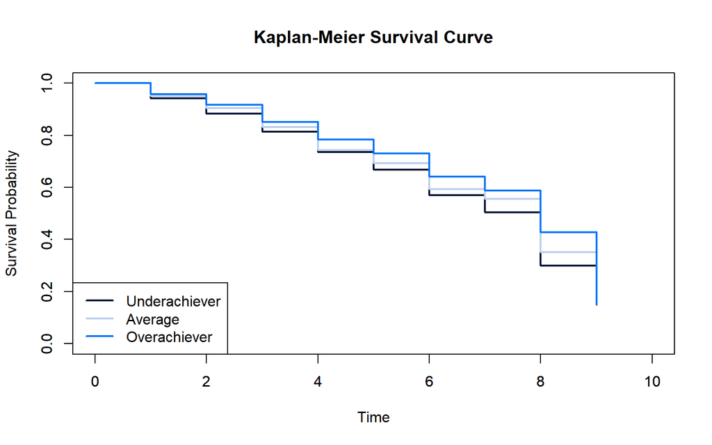

```
## Call:
## survdiff(formula = Surv(as.integer(VISCODE), EcogSPVisspat_cut) ~
##     thirtile_res, data = .)
##
## n=3953, 3364 observations deleted due to missingness.
##
##                   N Observed Expected (O-E)^2/E (O-E)^2/V
## thirtile_res=1 1846      688      616      8.39      17.4
## thirtile_res=3 2107      602      674      7.67      17.4
##
##  Chisq= 17.4  on 1 degrees of freedom, p= 3e-05
```

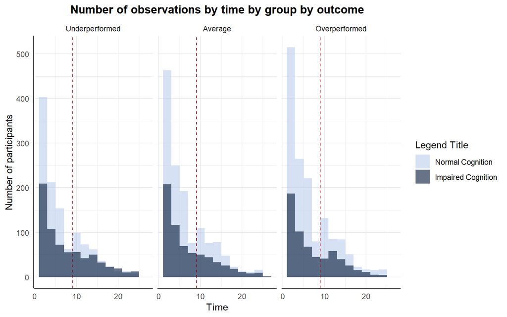

### EcogSP Total ???

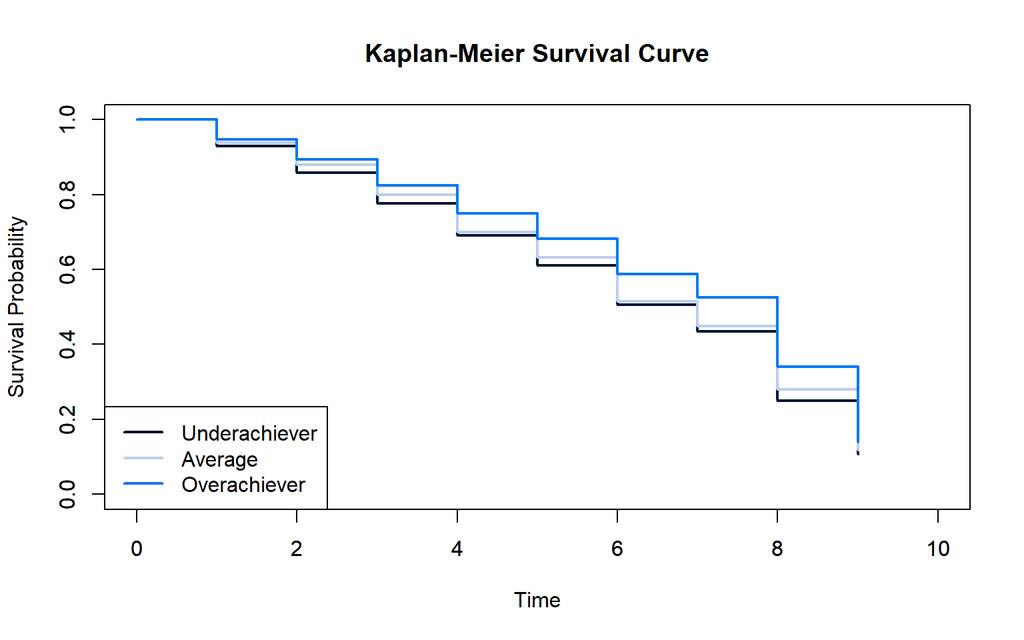

```
## Call:
## survdiff(formula = Surv(as.integer(VISCODE), EcogSPTotal_cut) ~
##     thirtile_res, data = .)
##
## n=3981, 3336 observations deleted due to missingness.
##
##                   N Observed Expected (O-E)^2/E (O-E)^2/V
## thirtile_res=1 1871      800      725      7.84      16.5
## thirtile_res=3 2110      698      773      7.35      16.5
##
##  Chisq= 16.5  on 1 degrees of freedom, p= 5e-05
```

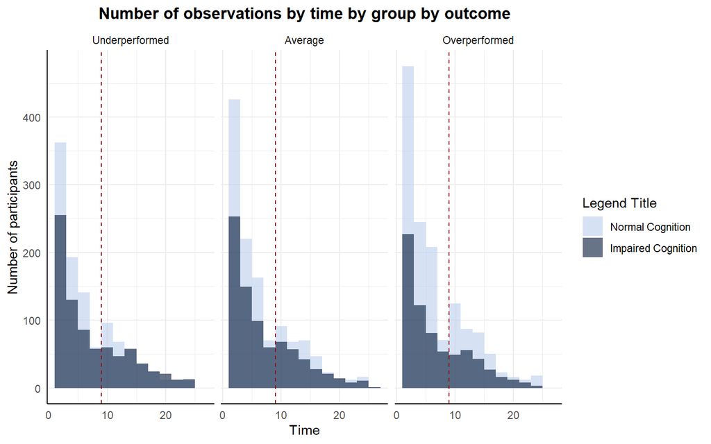

```r
test <- long_dat %>% filter(AGE %in% 60:70)

# also test # people 65 to 75
```